# Sup-patient1-tumor-Seurat3.0

jmzeng1314@163.com

21 July, 2019

## 引言

这里直接读取作者给定的第一个病人的Gene expression analysis: discovery patient tumor，用的是 10x genomics 3’ Chromium expression assay.

Following sequence alignment and filtering, a total of 7431 tumor cells

主要是比较免疫治疗前后的肿瘤细胞的免疫变化，免疫治疗前有2243 cells ，免疫治疗后是3个时间点，细胞数量多一点，是5188 cells

## 载入必要的R包

需要自行下载安装一些必要的R包！ 而且需要注意版本 Seurat

因为大量学员在中国大陆，通常不建议大家使用下面的R包安装方法，建议是切换镜像后再下载R包。

参考：http://www.bio-info-trainee.com/3727.html

```r
if (!requireNamespace("BiocManager"))
    install.packages("BiocManager")
if (!requireNamespace("Seurat"))
    BiocManager::install("Seurat")
```

加载R包

```r
rm(list = ls()) # clear the environment
#load all the necessary libraries
options(warn=-1) # turn off warning message globally
suppressMessages(library(Seurat))
```

## 读入文章关于第一个病人的tumor表达矩阵

```r
start_time <- Sys.time()
raw_dataTumor <- read.csv('../Output_2018-03-12/GSE117988_raw.expMatrix_Tumor.csv.gz', header = TRUE, row.names = 1)
end_time <- Sys.time()
end_time - start_time # for 2.7 GHz i5, 8G RAM, total = 1.8min
```

```
## Time difference of 58.07453 secs
```

```r
dim(raw_dataTumor) # 7,431 cells and 21,861 genes - already filtered
```

```
## [1] 21861  7431
```

```r
dataTumor <- log2(1 + sweep(raw_dataTumor, 2, median(colSums(raw_dataTumor))/colSums(raw_dataTumor), '*')) # Normalization

# 3.0版本取消了ExtractField
# 版本2 cellTypes <- sapply(colnames(dataTumor), function(x) ExtractField(x, 2, '[.]'))

cellTypes <- sapply(colnames(dataTumor), function(x) unlist(strsplit(x, "\\."))[2])
cellTypes <-ifelse(cellTypes == '1', 'Tumor_Before', 'Tumor_AcquiredResistance')
table(cellTypes)
```

```
## cellTypes
## Tumor_AcquiredResistance             Tumor_Before
##                     5188                     2243
```

```r
## 实际上原文里面的不仅仅是治疗前后的比较，还有治疗期间的3个时间点。
```

## 表达矩阵的质量控制

简单看看表达矩阵的性质，主要是基因数量，细胞数量;以及每个细胞表达基因的数量，和每个基因在多少个细胞里面表达。

```r
fivenum(apply(dataTumor,1,function(x) sum(x>0) ))
```

```
##    VP2 GPRIN2   EML3 ZNF140  RPLP1
##      1      8    103    566   7431
```

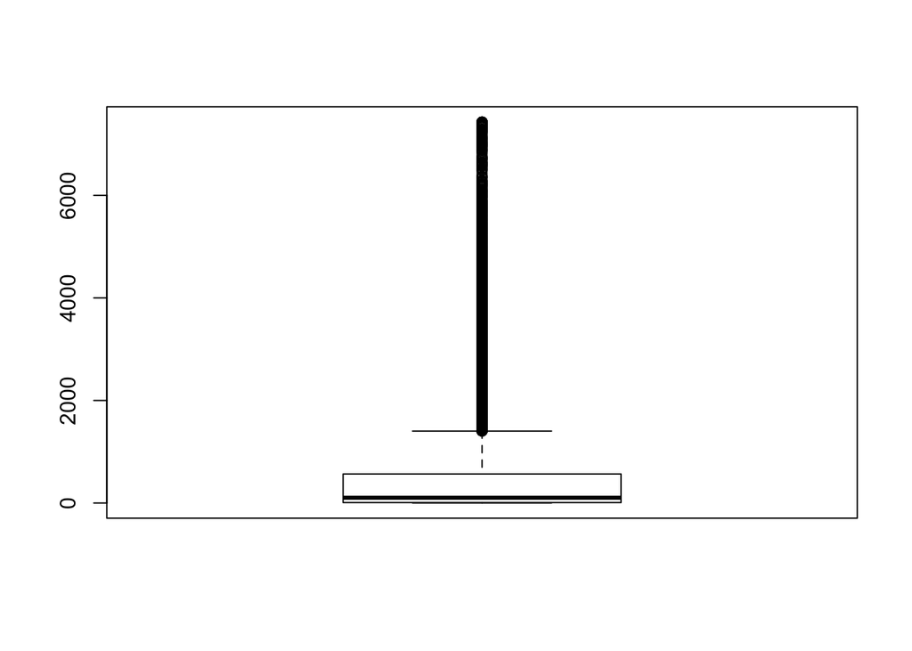

```r
boxplot(apply(dataTumor,1,function(x) sum(x>0) ))
```

```r
fivenum(apply(dataTumor,2,function(x) sum(x>0) ))
```

```
## GGAACTTAGGAATCGC.1 TACGGTACAAGCCGCT.2 CCTACCAAGCGTGAGT.1
##              192.0             1059.0             1380.0
## TGAGCCGAGACTAGAT.2 GATCGTAGTCATATGC.2
##             1971.5             5888.0
```

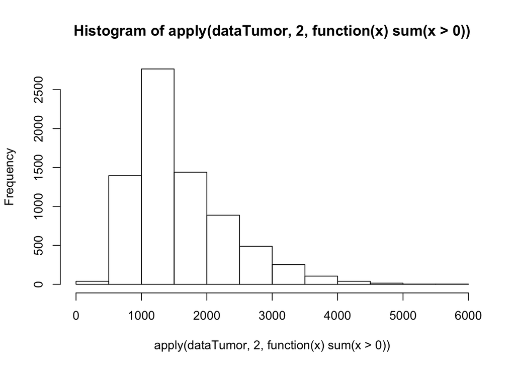

```r
hist(apply(dataTumor,2,function(x) sum(x>0) ))
```

## 然后创建Seurat的对象

```r
# Create Seurat object
# 与2.0版本对比
# tumor <- CreateSeuratObject(raw.data = dataTumor, min.cells = 1, min.genes = 0, project = '10x_Tumor')
tumor <- CreateSeuratObject(dataTumor, min.cells = 1, min.features = 0, project = '10x_Tumor') # already normalized
tumor # 21,861 genes and 7,431 cells
```

```
## An object of class Seurat
## 21861 features across 7431 samples within 1 assay
## Active assay: RNA (21861 features)
```

```r
# Add meta.data (nUMI and cellTypes)
# 3.0版本可以直接使用 object$name <- vector，当然也可以用AddMetaData
tumor <- AddMetaData(object = tumor,
                     metadata = apply(raw_dataTumor, 2, sum),
                     col.name = 'nUMI_raw')
tumor <- AddMetaData(object = tumor, metadata = cellTypes, col.name = 'cellTypes')
```

## 一些质控

这里绘图，可以指定分组，前提是这个分组变量存在于meta信息里面，我们创建对象后使用函数添加了 cellTypes 属性，所以可以用来进行可视化。

这里是：‘cellTypes’，就是免疫治疗前后。

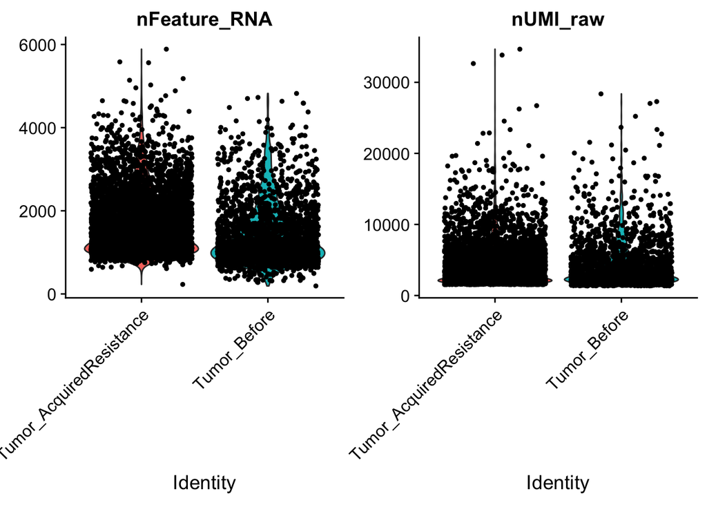

```r
sce=tumor
features=c("nFeature_RNA", "nUMI_raw")
VlnPlot(object = sce,
        features = features,
        group.by = 'cellTypes', ncol = 2)
```

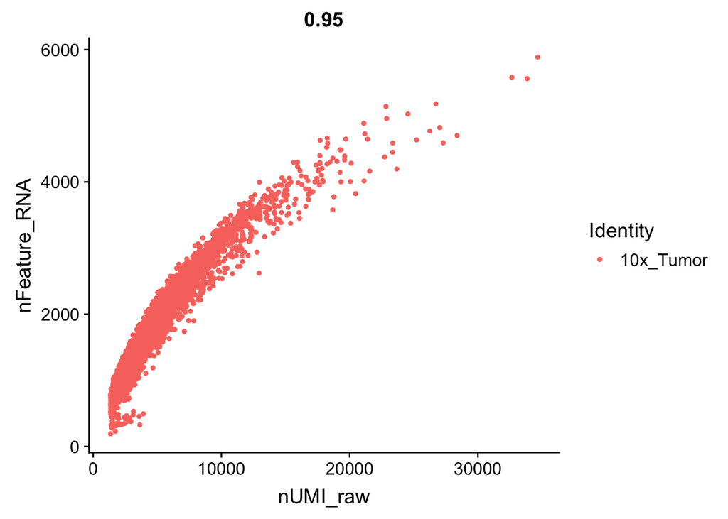

```r
# 3.0版本将GenePlot替换为FeatureScatter
# 版本2 GenePlot(object = sce, gene1 = "nUMI", gene2 = "nGene")
FeatureScatter(sce,feature1 = "nUMI_raw",feature2 = "nFeature_RNA")
```

可以看看高表达量基因是哪些

```r
# 3.0版本要将sce@raw.data替换成GetAssayData(object = , assay= ,slot = )
tail(sort(Matrix::rowSums(GetAssayData(sce,assay = "RNA"))))
```

```
##     RPS2   MT-CO1   MT-CO3   MT-CO2    RPS18   MALAT1
## 34406.98 35104.22 35400.39 36274.50 36712.57 47996.87
```

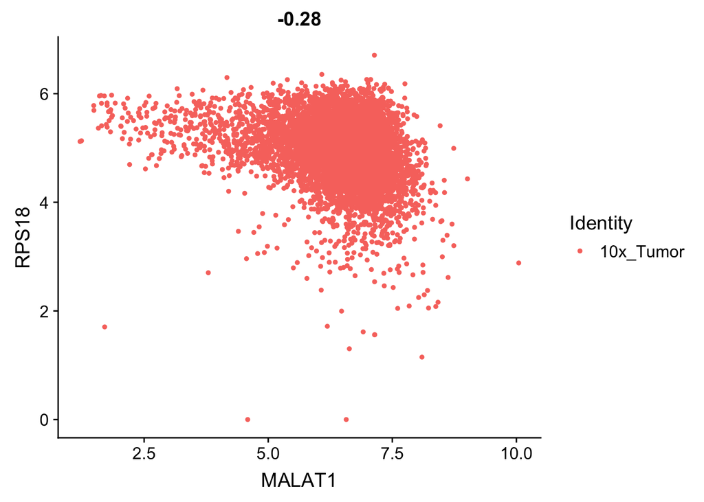

```r
## 散点图可视化任意两个基因的一些属性（通常是细胞的度量）
# 这里选取两个基因。
tmp=names(sort(Matrix::rowSums(GetAssayData(sce,assay = "RNA")),decreasing = T))
# 版本2 GenePlot(object = sce, gene1 = tmp[1], gene2 = tmp[2])
FeatureScatter(object = sce, feature1 = tmp[1], feature2 = tmp[2])
```

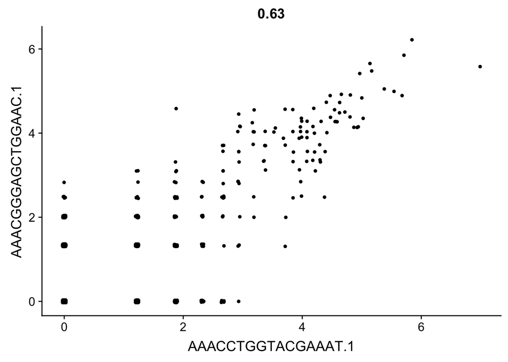

```r
# 散点图可视化任意两个细胞的一些属性（通常是基因的度量）
# 这里选取两个细胞

# 3.0版本将CellPlot替换成CellScatter，sce@cell.names换为colnames
# 版本2 CellPlot(sce,sce@cell.names[3],sce@cell.names[4],do.ident = FALSE)
CellScatter(sce, colnames(sce)[3],colnames(sce)[4])
```

## 最后标准聚类可视化

```r
start_time <- Sys.time()
# Cluster tumor cells
tumor <- ScaleData(object = tumor, vars.to.regress = c('nUMI_raw'), model.use = 'linear', use.umi = FALSE)

# 3.0版本将FindVariableGenes换为FindVariableFeatures，另外将原来的cutoff进行整合，x轴统一归到mean.cutoff中，y轴归到dispersion.cutoff中
# 版本2 tumor <- FindVariableGenes(object = tumor, mean.function = ExpMean, dispersion.function = LogVMR, x.low.cutoff = 0.0125, x.high.cutoff = 3, y.cutoff = 0.5)
tumor <- FindVariableFeatures(object = tumor, mean.function = ExpMean, dispersion.function = LogVMR, mean.cutoff = c(0.0125,3), dispersion.cutoff = c(0.5,Inf))

tumor <- RunPCA(object = tumor, pc.genes = VariableFeatures(tumor))
```

```
## PC_ 1
## Positive:  STMN1, HNRNPA2B1, CBX3, TUBB2B, PHF14, HMGN2, NDUFA4, SUB1, UCHL1, TUBA1A
##     MDK, PCDH9, ZFAS1, ILF2, CALM2, PRDX2, DEK, CCER2, SOX4, NEFM
##     CCT5, MARCKSL1, TUBB, KRT18, NHLH1, HMGB2, CCT6A, CKB, HIST1H4C, HSP90AB1
## Negative:  CD74, HLA-DRA, S100A11, HLA-DPB1, HLA-DRB1, TYROBP, HLA-DPA1, VIM, LGALS1, C1QB
##     SAT1, C1QA, SRGN, CTSB, NPC2, SOD2, FCER1G, CD68, APOE, HLA-DQB1
##     HLA-B, HLA-DQA1, APOC1, LAPTM5, CTSS, HLA-DRB5, AIF1, C1QC, PSAP, TYMP
## PC_ 2
## Positive:  SELM, MT-CO3, CD44, MT-ATP6, S100A1, S100A16, MYO15A, MT-CYB, RBP7, LGALS7B
##     MT-ND3, NEAT1, CCER2, MT-ND2, CYBA, PSTPIP1, PCP4, ATP5J, ADAMTS7, PHLDA2
##     RPL22L1, HIST1H1C, PGF, IGKC, POLR2L, H1F0, CDKN1A, SH3BGRL3, S100A2, TFAP2B
## Negative:  HSP90AA1, ACTB, HNRNPA2B1, TUBA1A, HSPA8, ACTG1, HSP90AB1, TUBA1B, HSPD1, TUBB2B
##     CALM2, DNAJA1, BASP1, HMGB2, UBB, UBC, SUB1, VAPA, DNAJB6, HSPH1
##     KPNA2, HSPB1, CKS2, HSPA1A, CACYBP, PCDH9, UBE2S, CCT5, H3F3B, PTTG1
## PC_ 3
## Positive:  IGFBP7, IFITM3, SPARC, CALD1, MGP, NNMT, SPARCL1, TM4SF1, EMP1, IFI27
##     CAV1, LAMA4, IGFBP4, IFITM2, COL4A2, PTRF, TIMP1, COL4A1, COL3A1, COL1A1
##     BGN, PRSS23, C1R, COL6A2, CCL2, COL1A2, GNG11, FSTL1, FN1, ZFP36L1
## Negative:  C1QB, C1QA, TYROBP, FCER1G, CD68, AIF1, APOC1, C1QC, HLA-DQA1, LYZ
##     HLA-DQB1, CTSB, C15orf48, LAPTM5, ITGB2, GPR183, CAPG, HLA-DMB, APOE, HLA-DPA1
##     CTSD, C5AR1, PCP4, SDS, LST1, LIPA, MS4A7, ACP5, HLA-DRA, MS4A6A
## PC_ 4
## Positive:  HSPA1A, ZFAND2A, DNAJB1, HSPB1, HSPA1B, HSPH1, HSPA6, ATF3, SERPINH1, JUN
##     CHORDC1, SNHG15, DEDD2, DNAJA4, CLK1, MRPL18, DNAJB6, HSP90AB1, RSRC2, HSPD1
##     CACYBP, FKBP4, SNHG8, IER2, HSP90AA1, BAG3, DNAJA1, TCP1, ZFAS1, HERPUD1
## Negative:  HMGN2, UBE2C, H2AFZ, PTTG1, STMN1, CALM2, BIRC5, CKS1B, UBE2S, HMGB1
##     CENPF, HMGB2, TMSB10, TOP2A, CENPA, MKI67, CCNB2, TUBB4B, GSTP1, HN1
##     HIST1H4C, ASPM, CCNB1, PRDX2, NUF2, NDUFA4, NUSAP1, TMSB4X, PCP4, TUBA1B
## PC_ 5
## Positive:  TOP2A, UBE2C, CENPF, CKS1B, BIRC5, ASPM, CCNB1, CCNB2, MKI67, NUF2
##     CENPA, NUSAP1, PIF1, SMC4, KPNA2, CKS2, HMGB2, PTTG1, TUBA1C, ARL6IP1
##     HIST1H4C, UBE2S, NUCKS1, IGKC, TUBB4B, CD44, JUN, ATF4, ISG20, CREB5
## Negative:  CHGA, VIP, NPY, CD63, MDK, KRT18, PCSK1N, ENO1, KRT8, ALDOA
##     NDUFS6, TPI1, NDUFA4, CCER2, SUB1, UCHL1, CCK, NDUFB2, SEC61G, PRDX2
##     S100A6, MARCKSL1, FTL, CKB, CST3, MYL6, PGK1, GSTP1, NDUFV2, PCDH9
```

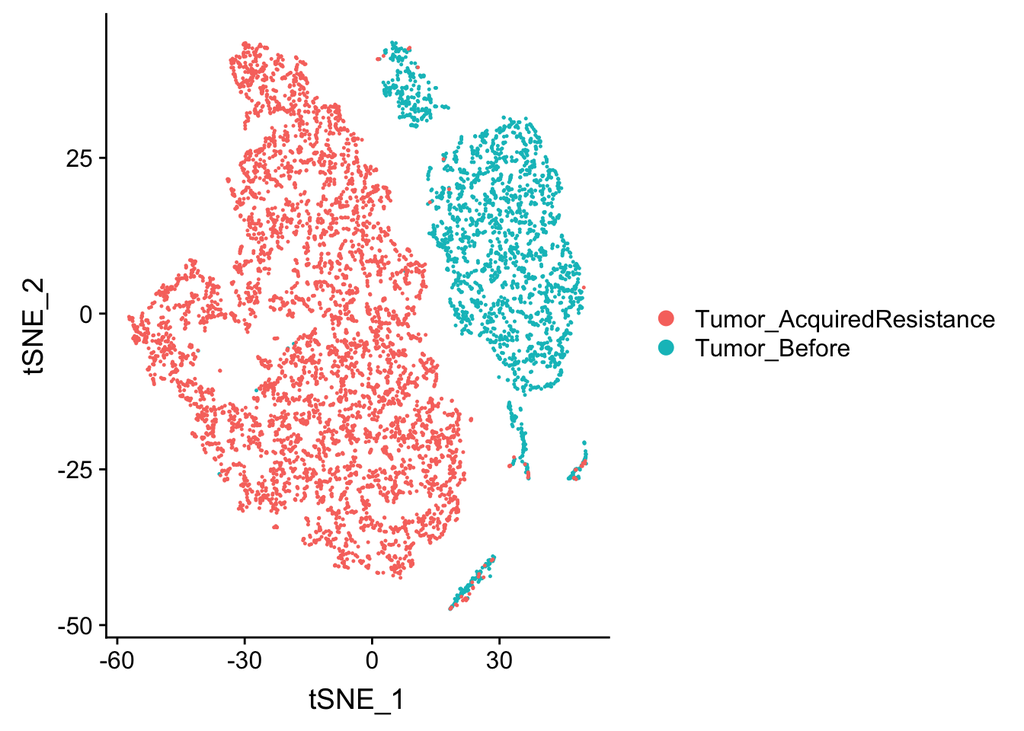

```r
tumor <- RunTSNE(object = tumor, dims.use = 1:10, perplexity = 25)
DimPlot(tumor, group.by = 'cellTypes', colors.use = c('#EF8A62', '#67A9CF'))
```

```r
end_time <- Sys.time()
end_time - start_time  # for 2.7 GHz i5, 8G RAM, total = 48.37729
```

```
## Time difference of 24.00287 mins
```

```r
#  这里文章里面没有运行 FindClusters ，仅仅是使用 cellTypes
```

同样的，也是需要marker基因来把肿瘤细胞进行分类，最后文章效果图是：

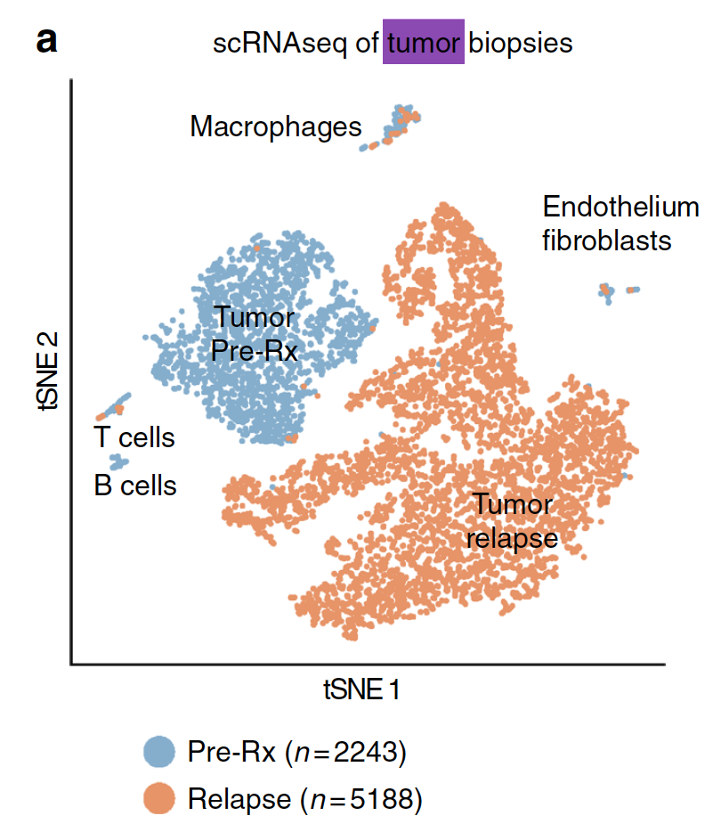

需要的marker基因也是附件，如下：

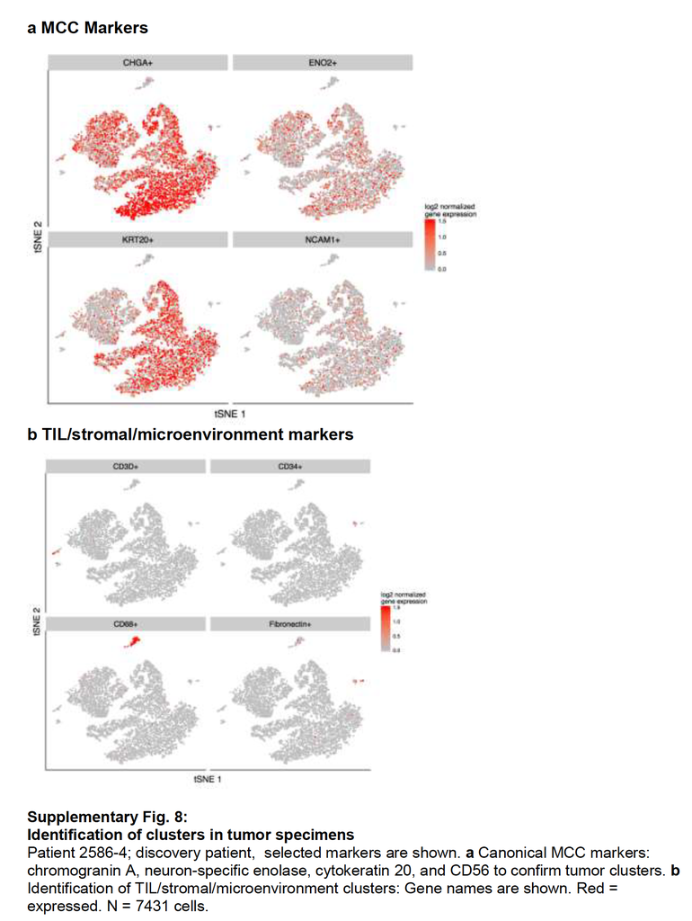